# PRESENTACIÓN PROGRA II slides

DATA CLEANING CON R

Programación II

Mariela Lizeth Benavides Lázaro  
Ernesto René Monterroso Zamora  
Allan Fernando Santizo Flores

[figure not shown]

Referencia bibliográfica

https://cran.r-project.org/doc/contrib/de_Jonge+van_der_Loo-Introduction_to_data_cleaning_with_R.pdf

[figure not shown]

INTRODUCCIÓN

El análisis de datos es un proceso de inspección, limpieza, transformación y modelado de datos con el objetivo de resaltar información útil, sugerir conclusiones y apoyar la toma de decisiones.

Es poco probable que los datos sin procesar con los que se trabaja estén en el formato correcto, sin errores, completos y con las etiquetas y códigos correctos que se necesitan para su análisis. Por lo que, la limpieza de datos es considerada una parte esencial del análisis estadístico ya que se necesitará en la mayoría de casos transformar datos en bruto en datos consistentes para que puedan ser analizados.

En la práctica, a menudo lleva más tiempo que el análisis estadístico en sí. Por lo que, se describirán a continuación una variedad de técnicas, implementadas en el entorno estadístico R, proporcionando elementos para incluir en scripts de limpieza de datos, para bases que sufren una amplia gama de errores e inconsistencias.

Entre los aspectos considerados se incluyen verificación de datos, localización de errores y una introducción a los métodos de imputación en R. Se presentan los problemas que comunmente es necesario resolver y la forma en que pueden abordarse utilizando distintos paquetes de R.

```r
#Librerias
#install.packages("readxl")
library(readxl)
#install.packages("validate")
library(validate)
#install.packages("stringr")
library(stringr)
#install.packages("igraph")
library(igraph)
#install.packages("editrules")
library(editrules)
#install.packages("deducorrect")
library(deducorrect)
#install.packages("lattice")
library(lattice)
#install.packages("survival")
library(survival)
#install.packages("Formula")
library(Formula)
#install.packages("ggplot2")
library(ggplot2)
#install.packages("Hmisc")
library(Hmisc)
#install.packages("VIM")
library(VIM)
#install.packages("colorspace")
library(colorspace)
#install.packages("grid")
library(grid)
#install.packages("data.table")
library(data.table)
#install.packages("rspa")
library(rspa)
```

## 1. ASPECTOS GENERALES

1.1. Análisis Estadístico

Se tratará el análisis estadístico como el resultado de una serie de pasos de procesamiento de datos donde cada paso aumenta el "valor de los datos".

El proceso se reduce a un conjunto de pasos:

[figure not shown]

1.2. Valores especiales a considerar en las bases de datos

Como la mayoría de los lenguajes de programación, R tiene una serie de valores especiales que son excepciones avalores normales de un tipo específico. Estos son NA, NULL, ± Inf y NaN. Existen diferencias entre ellos que será necesario identificar al realizar tratamiento de datos.

- NA: utilizado para indicar datos no disponible, NA es un marcador de posición para un valor faltante. Todas las operaciones básicas en R manejan NA sin generar errores en su ejecución y en su mayoría devuelven NA como respuesta siempre que una de las entradas del argumento es NA. Es posible utilizar la función "is.na" para detectar valores faltantes.

```r
d= ENEI20181P$PPA11
b <- cbind(1,nrow(ENEI20181P))

for (i in 1:nrow(ENEI20181P))
    {
    a=is.na(d[i])
    b[i]=a
        }

cat("La cantidad de NA en PPA11 es: ", sum(b))
```

```
La cantidad de NA en PPA11 es:  13321
```

- NULL : Se puede pensar en este tipo de valores como el conjunto vacío de las matemáticas. NULL es especial ya que no tiene clase (su clase es NULL) y tiene una longitud 0, por lo que no ocupa espacio en un vector. Es posible utilizar la función "is.null" para detectar variables NULL.

```r
length(c(1, 2, NULL, 4))
```

3

- Inf : hace referencia al infinito y solo se aplica a vectores de clase numérica. Un vector de clase entero no puede ser inf, en R Inf esta derivada únicamente para flotantes. Técnicamente, Inf es un valor numérico válido que resulta de cálculos como la división de un número por cero. Como Inf es un valor numérico, las operaciones entre Inf y un número finito están bien definidos y los operadores de comparación funcionan como se espera

```r
#Siendo P04C10 = Salario, P04C30= Tiempo de trabajo

M= ENEI20181P$P04C10 / ENEI20181P$P04C30
M[1:15]
```

1. 250

2. <NA>

3. 983.333333333333

4. <NA>

5. Inf

6. Inf

7. <NA>

8. <NA>

9. <NA>

10. <NA>

11. Inf

12. <NA>

13. 750

14. 114.814814814815

15. <NA>

- Nan: Indica que no hay un número. Este es generalmente el resultado de un cálculo cuyo resultado es desconocido, pero seguramente no es un número. En operaciones particulares como 0/0 , Inf-Inf y Inf / Inf resulta en NaN. Técnicamente, NaN es de clase numérica, lo que puede parecer extraño ya que se usa para indicar que algo no es numérico. Cálculos que involucran números y NaN siempre da como resultado NaN. Es posible utilizar la función "is.nan" para detectar Nan's.

```r
#Siendo PPA11 = cantidad de hijos , P04C30= nivel educativo


A= ENEI20181P$PPA11 / ENEI20181P$P04C30
A[145:150]
```

1. 0.0666666666666667

2. <NA>

3. NaN

4. <NA>

5. 0.0666666666666667

6. <NA>

## 2. Información bruta $\to$ Datos técnicamente correctos

2.1 Datos técnicamente correctos en R

El ambiente de R es capaz de leer y procesar distintas bases de datos de diferentes archivos. Vamos a referirnos a datos técnicamente correctos a aquellos que cumplen lo siguiente:

1. Está resguardada en un DataFrame con columnas nombradas,
2. Cada columna del DataFrame es el tipo de R que mejor representa el valor dominante de las variables de la columna.

Antes de empezar a transformar los datos, es recomendable hacer una rápida inspección de los mismos, para lo cual se pueden utilizar las siguientes funciones

```r
archivo <- read_xlsx("C:/Users/IN_CAP02/Desktop/proyecto/ENEI20181PO.xlsx")
#lectura del archivo de excel, cuyos datos serán utilizados para una rápida inspección.
class(archivo) # se consulta la clase del archivo
dim(archivo)   # se consulta la dimensión del archivo, primero filas y segundo columnas
names(archivo[1:20]) # se consulta el nombre de las columnas del archivo
```

1. 'tbl_df'

2. 'tbl'

3. 'data.frame'

1. 22310

2. 265

1. 'DOMINIO'

2. 'AREA'

3. 'UPM'

4. 'Factor_expansion'

5. 'NUM_HOGAR'

6. 'ID'

7. 'PPA02'

8. 'PPA03'

9. 'PPA04A'

10. 'PPA04B'

11. 'PPA04C'

12. 'PPA05'

13. 'PPA06'

14. 'PPA07'

15. 'PPA08'

16. 'PPA09'

17. 'PPA10A'

18. 'PPA10B'

19. 'PPA11'

20. 'PPA12'

```r
str(archivo$PPA04A)     # muestra de manera compacta la estructura del DataFrame
summary(archivo$PPA04A) # muestra un resumen con datos estadísticos del DataFrame
```

```
 num [1:22310] 13 6 25 5 30 13 29 22 28 16 ...
```

```
   Min. 1st Qu.  Median    Mean 3rd Qu.    Max.
   1.00    8.00   15.00   15.24   22.00   31.00
```

```r
head(archivo, n=3)  # muestra las primeras n filas del DataFrame
tail(archivo, n=3)  # muestra las últimas n filas del DataFrame
```

A tibble: 3 × 265

| DOMINIO <dbl> | AREA <dbl> | UPM <dbl> | Factor_expansion <dbl> | NUM_HOGAR <dbl> | ID <dbl> | PPA02 <dbl> | PPA03 <dbl> | PPA04A <dbl> | PPA04B <dbl> | ... | P05A21A <dbl> | P05A21B <dbl> | ETNICIDAD <dbl> | PET <dbl> | PEA <dbl> | OCUPADOS <dbl> | DESOCUPADOS <dbl> | SUBVISIBLES <dbl> | INACTIVOS <dbl> | FORMAL_INFORMAL <dbl> |
| --- | --- | --- | --- | --- | --- | --- | --- | --- | --- | --- | --- | --- | --- | --- | --- | --- | --- | --- | --- | --- |
| 1 | 1 | 1 | 217 | 1 | 1 | 1 | 65 | 13 | 8 | ... | 2 | NA | 2 | 1 | 1 | 1 | NA | NA | NA | 1 |
| 1 | 1 | 1 | 217 | 1 | 2 | 2 | 67 | 6 | 11 | ... | NA | NA | 2 | 1 | 1 | 1 | NA | NA | NA | 1 |
| 1 | 1 | 1 | 217 | 1 | 3 | 1 | 23 | 25 | 4 | ... | NA | NA | 2 | 1 | 1 | 1 | NA | NA | NA | 2 |

A tibble: 3 × 265

| DOMINIO <dbl> | AREA <dbl> | UPM <dbl> | Factor_expansion <dbl> | NUM_HOGAR <dbl> | ID <dbl> | PPA02 <dbl> | PPA03 <dbl> | PPA04A <dbl> | PPA04B <dbl> | ... | P05A21A <dbl> | P05A21B <dbl> | ETNICIDAD <dbl> | PET <dbl> | PEA <dbl> | OCUPADOS <dbl> | DESOCUPADOS <dbl> | SUBVISIBLES <dbl> | INACTIVOS <dbl> | FORMAL_INFORMAL <dbl> |
| --- | --- | --- | --- | --- | --- | --- | --- | --- | --- | --- | --- | --- | --- | --- | --- | --- | --- | --- | --- | --- |
| 3 | 2 | 363 | 842 | 5190 | 2 | 2 | 34 | 24 | 7 | ... | NA | NA | 1 | 1 | 1 | 1 | NA | NA | NA | 1 |
| 3 | 2 | 363 | 842 | 5190 | 3 | 2 | 2 | 18 | 4 | ... | NA | NA | 1 | NA | NA | NA | NA | NA | NA | NA |
| 3 | 2 | 363 | 842 | 5191 | 1 | 2 | 65 | 6 | 6 | ... | 2 | NA | 2 | 1 | NA | NA | NA | NA | 1 | NA |

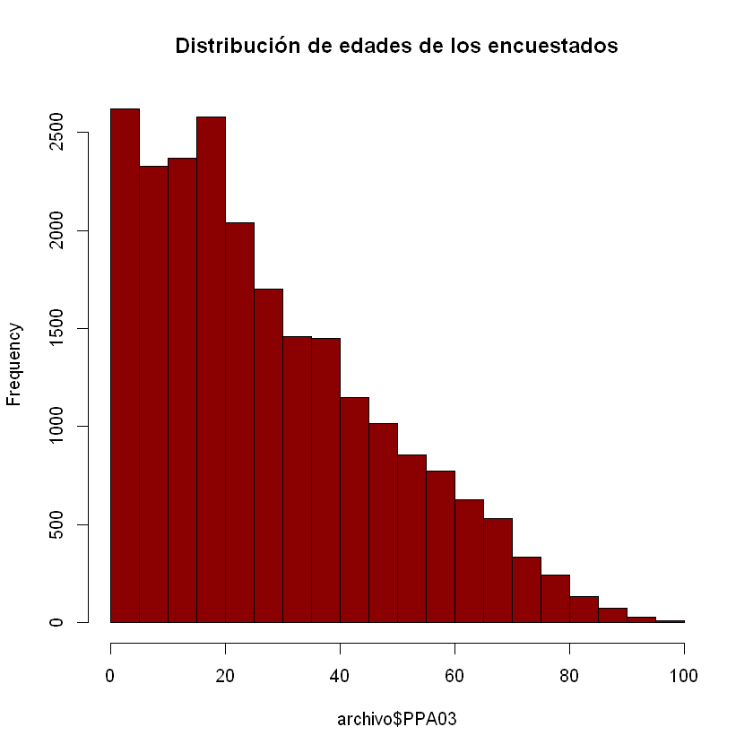

```r
hist(archivo$PPA03, main="Distribución de edades de los encuestados", col="Darkred") # Un histograma de los datos
```

2.2 Convertir el tipo de los elementos

Convertir una variable de un tipo a otro se llama coerción. Al momento de importar un archivo, R intentará determinar la clase según los datos de cada columna, a menos que se le indique desde un principio el tipo al que debe pertenecer.

```r
clases = sapply(archivo, class)
# Con este comando se puede verificar el tipo de elemento por cada columna
sum(clases=="numeric")
# Si se tienen demasiadas columnas, es mejor confirmar que todas tengan el tipo deseado
sum(clases=="logical")
# se determinó que varias columnas no tienen el tipo deseado
```

256

9

```r
ENEI20181P <- read_xlsx("C:\\Users\\IN_CAP02\\Desktop\\proyecto\\ENEI20181PO.xlsx", col_types = "numeric")
# Se indica el tipo de columnas, para que R entienda cómo deseamos la información
sum(sapply(ENEI20181P, class)=="numeric")
# El número de variables de clase numerica, coincide con el total de columnas del archivo
```

265

2.3 Validación de Datos

Esta se refiere a la actividad de verificar si un conjunto de datos cumple ciertas condiciones. Por ejemplo, si se tiene información de salarios, no se esperaría encontrar datos negativos, por lo que es una herramienta útil de aplicar para corroborar los datos que se van a procesar. Las condiciones a probarse pueden ser combinadas, y dependerán del tipo de información con la que se cuenta.

```r
migracion <- read.csv("C:\\Users\\IN_CAP02\\Desktop\\proyecto\\MIGRACION_BDP.csv")

reglas <- validator(DEPARTAMENTO>0,MUNICIPIO>0,COD_MUNICIPIO>0,ZONA>0,AREA>0,NUM_VIVIENDA>0,
                    NUM_HOGAR>0, ID_EMIGRACION>0, PEI3>0, PEI4>=0, PEI5>2000)
# comando para crear reglas
confront(migracion,reglas)
# comando para aplicar las reglas a las columnas
```

```
Object of class 'validation'
Call:
    confront(dat = migracion, x = reglas)

Confrontations: 11
With fails    : 0
Warnings      : 0
Errors        : 0
```

2.4 Factores de Recodificación

En algunas bases de datos, el valor de ciertas variables categóricas se almacena en un factor variable. Un factor es un vector de enteros con una tabla especificando el valor de entero correspondiente a cada nivel. Por ejemplo, en la base de datos "Migracion" se encuentra la columna "PEI3" que almacena el género de los individuos con los valores 1 y 2. El 1 es para Masculino y el 2 para Femenino. Si en lugar de mostrar 1 y 2, se desea mostrar el texto "masculino" y "femenino", se puede recodificar la DataFrame como se mostrará a continuación:

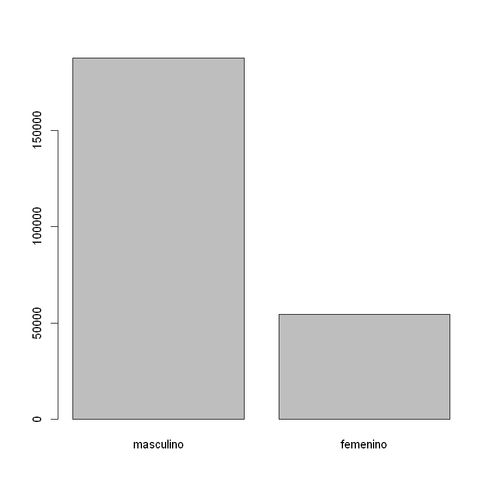

```r
recode <- c(masculino = 1, femenino = 2)
migracion$PEI3 = factor(migracion$PEI3, levels = recode, labels = names(recode))
plot(migracion$PEI3)
```

2.5 Otras funciones para transformar texto

```r
str_trim("  hello world  ") # elimina los espacios que están antes y después de la cadena de texto
str_trim("  hello world  ", side="right") # elimina los espacios que están después de la cadena de texto
str_trim("  hello world  ", side="left") # elimina los espacios que están están de la cadena de texto
str_pad(112, width = 6, side = "left", pad = 0) # modifica el texto al largo deseado
toupper("Hello world") # texto en mayúsculas
tolower("Hello World") # texto en minúsculas
```

'hello world'

' hello world'

'hello world '

'000112'

'HELLO WORLD'

'hello world'

```r
genero <- c("M", "masculino ", "Femenino", "fem.")
grepl("m", genero) # indica si los elementos contienen el caracter indicado
grep("m", genero)  # indica el índice del elemento que contenga el caracter indicado
grepl("m", tolower(genero)) # Se pueden usar funciones modificando la cadena de texto a evaluar
grepl("^m", genero, ignore.case = TRUE)
# con el caracter ^ se le indica a la función que busque en el primer caracter de cada elemento.
```

1. FALSE

2. TRUE

3. TRUE

4. TRUE

1. 2

2. 3

3. 4

1. TRUE

2. TRUE

3. TRUE

4. TRUE

1. TRUE

2. TRUE

3. FALSE

4. FALSE

## 3. Datos técnicamente correctos $\to$ Datos consistentes

Los datos consistentes son datos técnicamente correctos que son aptos para el análisis estadístico. Son datos en los que se eliminan, corrigen o imputan valores perdidos, valores especiales, errores (obvios) y valores atípicos. Los datos son consistentes con las restricciones basadas en el conocimiento del mundo real sobre el tema que describen los datos.

El proceso para contar con datos consistentes siempre implica los siguientes tres pasos.

1. **Detección** de una inconsistencia. Es decir, uno establece qué restricciones son violadas. Por ejemplo, una variable de edad está limitada a valores no negativos.
2. **Selección** del campo o campos que causan la inconsistencia. Esto es trivial en el caso de una demanda univariante como en el paso anterior, pero puede ser más engorroso cuando se espera que se mantengan las relaciones entre variables. Por ejemplo, el estado civil de un hijo debe ser soltero. En el caso de una violación, no está claro de inmediato si la edad, el estado civil o ambos están equivocados.
3. **Corrección** de los campos que el método de selección considera erróneos. Esto puede hacerse a través de métodos deterministas (basados en modelos) o estocásticos.

3.1 Detección y localización de errores.

### 3.1.1 Valores perdidos o faltantes

Un valor faltante, representado por NA en R, es un marcador de posición para un dato cuyo tipo es conocido pero su valor no lo es. Por lo tanto, es imposible realizar un análisis estadístico en los datos donde faltan uno o más valores en los datos. Se puede optar por omitir elementos de un conjunto de datos que contienen valores faltantes o imputar un valor, pero la falta es algo que debe abordarse antes de cualquier análisis.

```r
#No es posible hacer cálculos con valores perdidos.
mean(BASE$PPA10B)

#Es necesario utilizar la función base na.rm.
mean(BASE$P04C10,na.rm = TRUE)
```

<NA>

2501.94596003475

```r
#La siguiente función nos ayuda a identificar valores "NA".
is.na(BASE$PPA10B)[1:5]
```

1. TRUE

2. TRUE

3. TRUE

4. TRUE

5. FALSE

```r
#La siguiente función determina que si alguna fila de la base de datos tiene valores perdidos.
complete.cases(BASE$PPA10B)[1:10]
```

1. FALSE

2. FALSE

3. FALSE

4. FALSE

5. TRUE

6. TRUE

7. TRUE

8. FALSE

9. FALSE

10. FALSE

```r
#La siguiente función omite de la base de datos las filas con valores omisos.
head((a <- na.omit(BASE$PPA10B)),20)

#La siguiente función muestra que filas fueron extraídas de la base de datos.
head(na.action(a),20)
```

1. 1

2. 1

3. 1

4. 2

5. 2

6. 2

7. 2

8. 2

9. 2

10. 2

11. 2

12. 3

13. 1

14. 3

15. 1

16. 1

17. 1

18. 4

19. 2

20. 2

1. 1

2. 2

3. 3

4. 4

5. 8

6. 9

7. 10

8. 14

9. 15

10. 21

11. 22

12. 23

13. 26

14. 28

15. 29

16. 30

17. 31

18. 32

19. 37

20. 38

### 3.1.2 Valores especiales

Los cálculos que involucran valores especiales a menudo resultan en valores especiales, y dado que una afirmación estadística sobre un fenómeno del mundo real nunca debe incluir un valor especial, es deseable manejar valores especiales antes del análisis.

```r
# La función is.finite determina qué valores son valores 'regulares'.
is.finite(BASE$PPA10B)[1:30]
```

1. FALSE

2. FALSE

3. FALSE

4. FALSE

5. TRUE

6. TRUE

7. TRUE

8. FALSE

9. FALSE

10. FALSE

11. TRUE

12. TRUE

13. TRUE

14. FALSE

15. FALSE

16. TRUE

17. TRUE

18. TRUE

19. TRUE

20. TRUE

21. FALSE

22. FALSE

23. FALSE

24. TRUE

25. TRUE

26. FALSE

27. TRUE

28. FALSE

29. FALSE

30. FALSE

```r
#la siguiente función puede usarse para verificar cada columna numérica en un marco de datos.
is.special <- function(x){
    if (is.numeric(x)) !is.finite(x) else is.na(x)
}
head(is.special(BASE),5)
```

A matrix: 5 × 269 of type lgl

| No | DOMINIO | AREA | UPM | Factor_expansion | NUM_HOGAR | ID | PPA02 | SEXO | PPA03 | ... | P05A21A | P05A21B | ETNICIDAD | PET | PEA | OCUPADOS | DESOCUPADOS | SUBVISIBLES | INACTIVOS | FORMAL_INFORMAL |
| --- | --- | --- | --- | --- | --- | --- | --- | --- | --- | --- | --- | --- | --- | --- | --- | --- | --- | --- | --- | --- |
| FALSE | FALSE | FALSE | FALSE | FALSE | FALSE | FALSE | FALSE | FALSE | FALSE | ... | FALSE | TRUE | FALSE | FALSE | FALSE | FALSE | TRUE | TRUE | TRUE | FALSE |
| FALSE | FALSE | FALSE | FALSE | FALSE | FALSE | FALSE | FALSE | FALSE | FALSE | ... | TRUE | TRUE | FALSE | FALSE | FALSE | FALSE | TRUE | TRUE | TRUE | FALSE |
| FALSE | FALSE | FALSE | FALSE | FALSE | FALSE | FALSE | FALSE | FALSE | FALSE | ... | TRUE | TRUE | FALSE | FALSE | FALSE | FALSE | TRUE | TRUE | TRUE | FALSE |
| FALSE | FALSE | FALSE | FALSE | FALSE | FALSE | FALSE | FALSE | FALSE | FALSE | ... | FALSE | TRUE | FALSE | FALSE | FALSE | FALSE | TRUE | TRUE | TRUE | FALSE |
| FALSE | FALSE | FALSE | FALSE | FALSE | FALSE | FALSE | FALSE | FALSE | FALSE | ... | TRUE | TRUE | FALSE | FALSE | FALSE | FALSE | TRUE | TRUE | TRUE | FALSE |

### 3.1.3 Valores atípicos

Existe una gran cantidad de literatura sobre detección de valores atípicos, y existen varias definiciones de valores atípicos. Una definición general de Barnett y Lewis define un valor atípico en un conjunto de datos como una observación (o conjunto de observaciones) que parece ser inconsistente con ese conjunto de datos.

La instalación base R viene con la función boxplot.stats, que, entre otras cosas, enumera los valores atípicos.

```r
# La siguiente función determina datos átipicos
boxplot.stats(BASE$P04C10)$out
```

1. 7000

2. 8000

3. 8000

4. 7000

5. 7000

6. 8000

7. 10000

8. 9000

9. 7000

10. 9000

11. 8000

12. 15000

13. 6000

14. 10300

15. 10000

16. 15000

17. 7000

18. 7000

19. 9000

20. 8000

21. 6100

22. 6000

23. 9000

24. 7000

25. 7000

26. 8200

27. 6500

28. 7000

29. 7000

30. 10000

31. 9000

32. 9000

33. 9000

34. 10000

35. 8000

36. 20000

37. 7000

38. 8000

39. 6000

40. 6000

41. 7000

42. 7000

43. 10000

44. 12000

45. 8000

46. 11000

47. 7000

48. 7000

49. 12000

50. 9000

51. 8000

52. 35000

53. 15000

54. 10000

55. 8000

56. 7000

57. 8000

58. 7500

59. 7000

60. 10000

61. 10000

62. 8000

63. 8000

64. 7000

65. 7000

66. 8000

67. 9500

68. 8000

69. 6000

70. 50000

71. 8000

72. 9000

73. 9000

74. 8500

75. 9000

76. 6000

77. 6000

78. 8000

79. 7000

80. 8000

81. 7000

82. 15000

83. 10000

84. 6500

85. 10000

86. 7000

87. 10000

88. 7500

89. 6500

90. 6500

91. 6200

92. 12000

93. 7000

94. 10000

95. 6000

96. 10000

97. 10000

98. 6500

99. 10000

100. 10000

101. 6000

102. 6000

103. 10000

104. 9000

105. 10000

106. 6000

107. 9000

108. 5900

109. 6000

110. 6150

111. 6000

112. 12000

113. 10422

114. 6000

115. 6000

116. 12000

117. 7500

118. 6000

119. 10000

120. 10000

121. 7000

122. 13000

123. 12000

124. 6000

125. 10000

126. 10000

127. 6000

128. 9300

129. 6000

130. 5900

131. 6000

132. 8000

133. 12000

134. 8000

135. 6000

136. 12000

137. 8000

138. 6000

139. 6000

140. 7000

141. 9000

142. 8000

143. 7300

144. 6000

145. 6000

146. 6000

147. 6000

148. 8000

149. 10000

150. 6000

151. 8000

152. 7200

153. 7000

154. 10000

155. 11000

156. 6000

157. 17000

158. 8000

159. 7000

160. 6000

161. 6500

162. 7000

163. 6000

164. 7000

165. 7200

166. 7000

167. 7000

168. 9000

169. 6500

170. 7000

171. 7000

172. 7000

173. 8000

174. 10000

175. 7000

176. 9000

177. 6000

178. 6000

179. 10000

180. 6000

181. 11000

182. 10000

183. 8000

184. 15000

185. 6900

186. 25000

187. 15000

188. 8000

189. 10000

190. 14000

191. 7000

192. 11000

193. 5779

194. 12000

195. 9000

196. 6000

197. 6000

198. 10000

199. 8000

200. 7000

201. 8000

202. 10000

203. 8000

204. 10000

205. 7000

206. 7000

207. 8000

208. 7000

209. 9000

210. 6000

211. 15000

212. 7000

213. 12000

214. 6000

215. 8000

216. 10000

217. 7200

218. 8000

219. 6680

220. 13000

221. 7000

222. 6000

223. 7292

224. 10000

225. 6300

226. 12000

227. 8203

228. 6380

229. 7000

230. 8800

231. 5800

232. 6000

233. 6000

234. 6000

235. 7200

236. 7000

237. 6000

238. 6500

239. 25000

240. 6000

241. 6000

242. 7000

243. 8000

244. 8000

245. 6000

246. 8000

247. 8000

248. 6000

249. 6600

250. 8000

251. 5800

252. 8000

253. 6500

254. 7400

255. 7200

256. 8712

257. 6600

258. 5800

259. 5800

260. 8500

261. 6587

262. 6300

263. 6000

264. 7220

265. 5750

266. 6300

267. 8000

268. 8000

269. 6000

270. 5800

271. 7210

272. 8000

273. 6000

274. 7000

275. 5800

276. 6000

277. 6000

278. 7000

279. 6000

280. 7000

281. 6225

282. 7100

283. 8500

284. 6000

285. 8000

286. 6300

287. 8203

288. 6000

289. 8000

290. 7260

291. 7260

292. 6000

293. 6000

294. 8000

295. 14000

296. 6380

297. 7000

298. 8000

299. 10000

300. 6000

301. 6000

302. 12000

303. 8500

304. 11000

305. 6000

306. 7000

307. 6000

308. 5800

309. 8000

310. 6000

311. 7203

312. 10000

313. 6000

314. 6580

315. 7200

316. 11300

317. 6000

318. 8000

319. 6000

```r
# Pueden modificarse las condiciones del Boxplot, un coeficiente más alto significa un límite de detección de valores atípicos más altos.
boxplot.stats(BASE$P04C10, coef=3)$out
```

1. 10000

2. 9000

3. 9000

4. 15000

5. 10300

6. 10000

7. 15000

8. 9000

9. 9000

10. 10000

11. 9000

12. 9000

13. 9000

14. 10000

15. 20000

16. 10000

17. 12000

18. 11000

19. 12000

20. 9000

21. 35000

22. 15000

23. 10000

24. 10000

25. 10000

26. 9500

27. 50000

28. 9000

29. 9000

30. 8500

31. 9000

32. 15000

33. 10000

34. 10000

35. 10000

36. 12000

37. 10000

38. 10000

39. 10000

40. 10000

41. 10000

42. 10000

43. 9000

44. 10000

45. 9000

46. 12000

47. 10422

48. 12000

49. 10000

50. 10000

51. 13000

52. 12000

53. 10000

54. 10000

55. 9300

56. 12000

57. 12000

58. 9000

59. 10000

60. 10000

61. 11000

62. 17000

63. 9000

64. 10000

65. 9000

66. 10000

67. 11000

68. 10000

69. 15000

70. 25000

71. 15000

72. 10000

73. 14000

74. 11000

75. 12000

76. 9000

77. 10000

78. 10000

79. 10000

80. 9000

81. 15000

82. 12000

83. 10000

84. 13000

85. 10000

86. 12000

87. 8800

88. 25000

89. 8712

90. 8500

91. 8500

92. 14000

93. 10000

94. 12000

95. 8500

96. 11000

97. 10000

98. 11300

### 3.1.4 Inconsistencias obvias

Una inconsistencia obvia ocurre cuando un registro contiene un valor o una combinación de valores que no pueden corresponder a una situación del mundo real. Por ejemplo, la edad de una persona no puede ser negativa, un hombre no puede estar embarazado y una persona menor de edad no puede poseer una licencia de conducir.

La comprobación de inconsistencias obvias se puede hacer directamente en R usando índices lógicos y reciclaje. Por ejemplo, para verificar qué elementos de x obedecen la regla `x no debe ser negativa ', simplemente se usa lo siguiente.

```r
# La siguiente verificación se realiza con verificaciones lógicas

x_nonnegative <- BASE$PPA03 >= 0
print(x_nonnegative[1:10])
```

```
 [1]  TRUE  TRUE  TRUE  TRUE FALSE  TRUE  TRUE  TRUE  TRUE  TRUE
```

#### Edit Rules

El paquete editrules permite definir reglas sobre conjuntos de datos categóricos, numéricos o de tipo mixto que cada registro debe obedecer. Además, editrules puede verificar qué reglas se obedecen y permite encontrar el conjunto mínimo de variables para adaptarlas de modo que se puedan obedecer todas las reglas. El paquete también implementa una serie de operaciones básicas de reglas que permiten a los usuarios probar conjuntos de reglas en busca de contradicciones y ciertas redundancias.

```r
# La siguiente condición verifica que el campo año de nacimiento contenga valores "consistentes".
(edad <- editset(c("PPA04C >=1939", "PPA04C <= 2018")))
#(activo <- editset(c("PPA04C >=2012", "PEA != NA")))

va <- violatedEdits(edad, BASE)
summary(va)
```

```
Edit set:
num1 : 1939 <= PPA04C
num2 : PPA04C <= 2018
```

```
Edit violations, 22310 observations, 0 completely missing (0%):

 editname freq  rel
     num1  313 1.4%

Edit violations per record:

 errors  freq   rel
      0 21997 98.6%
      1   313  1.4%
```

```r
# Las reglas pueden ser consignadas en un archivo de texto
reglas <- editfile("C:/Users/IN_CAP02/Desktop/proyecto/Reglas.txt")
ve<- violatedEdits(reglas,BASE)
summary(ve)
```

```
Edit violations, 22310 observations, 0 completely missing (0%):

 editname freq  rel
     mix2  344 1.5%

Edit violations per record:

 errors  freq   rel
      0 21966 98.5%
      1   344  1.5%
```

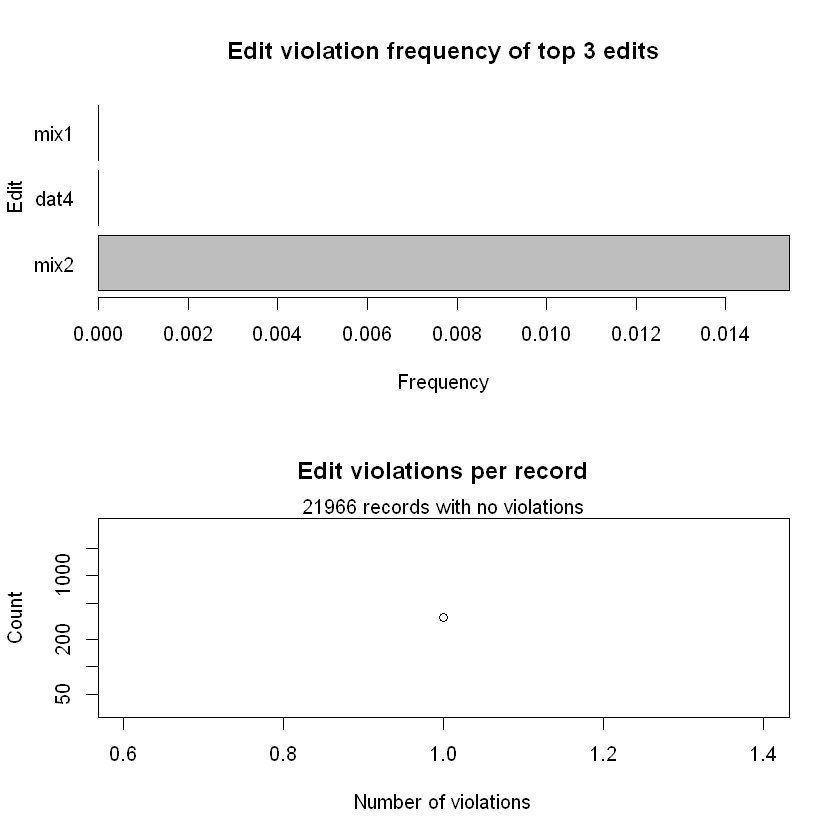

```r
plot(ve)
```

### 3.1.5 Error de localización

La interconectividad de las ediciones es lo que hace que la localización de errores sea difícil. Supongamos que modificamos algún campo para que no se viole una regla. Luego corremos el riesgo de violar otras ediciones que contengan edad.

```r
id <- c(2,12328)
violatedEdits(edad, BASE[id,])
le <- localizeErrors(edad, BASE[id, ], method = "mip")
```

```
      edit
record  num1  num2
     1 FALSE FALSE
     2  TRUE FALSE
```

```r
le <- localizeErrors(edad, BASE[id, ], method = "mip")
le$adapt
```

A matrix: 2 × 269 of type lgl

|  | No | DOMINIO | AREA | UPM | Factor_expansion | NUM_HOGAR | ID | PPA02 | SEXO | PPA03 | ... | P05A21A | P05A21B | ETNICIDAD | PET | PEA | OCUPADOS | DESOCUPADOS | SUBVISIBLES | INACTIVOS | FORMAL_INFORMAL |
| --- | --- | --- | --- | --- | --- | --- | --- | --- | --- | --- | --- | --- | --- | --- | --- | --- | --- | --- | --- | --- | --- |
| 1 | FALSE | FALSE | FALSE | FALSE | FALSE | FALSE | FALSE | FALSE | FALSE | FALSE | ... | FALSE | FALSE | FALSE | FALSE | FALSE | FALSE | FALSE | FALSE | FALSE | FALSE |
| 2 | FALSE | FALSE | FALSE | FALSE | FALSE | FALSE | FALSE | FALSE | FALSE | FALSE | ... | FALSE | FALSE | FALSE | FALSE | FALSE | FALSE | FALSE | FALSE | FALSE | FALSE |

3.2 Corrección

Los métodos de corrección apuntan a fijar observaciones inconsistentes al alterar valores no válidos en un registro basado en información de valores válidos. Dependiendo del método, este es un procedimiento de un solo paso o un procedimiento de dos pasos donde primero se usa un método de localización de errores para vaciar ciertos campos, seguido de un paso de imputación.

```r
(estaturas <- read.csv("C:\\Users\\IN_CAP02\\Desktop\\proyecto\\HNOS.csv", stringsAsFactors = FALSE))
```

A data.frame: 5 × 3

| name <chr> | height <dbl> | unit <chr> |
| --- | --- | --- |
| Diego | 120.00 | cm |
| Domingo | 1.30 | m |
| Pablo | 75.00 | inch |
| Elmer | 125.00 | cm |
| Polo | 6.01 | ft |

### 3.2.1 Reglas simples de transformación

En la práctica, los procedimientos de limpieza de datos implican muchas transformaciones ad-hoc. Esto puede conducir a grandes secuencias de comandos en las que se seleccionan partes de los datos, se modifican algunas variables, se selecciona otra parte, se modifican algunas variables más, etc. Sin embargo, a medida que los scripts se alargan, es mejor almacenar las reglas de transformación por separado y registrar qué regla se ejecuta en qué registro. El paquete deducorrect ofrece funcionalidad para esto.

```r
R <- correctionRules("C:\\Users\\IN_CAP02\\Desktop\\proyecto\\conversiones.txt")
cor <- correctWithRules(R, estaturas)
cor$corrected
```

A data.frame: 5 × 3

| name <chr> | height <dbl> | unit <chr> |
| --- | --- | --- |
| Diego | 1.200000 | m |
| Domingo | 1.300000 | m |
| Pablo | 1.905004 | m |
| Elmer | 1.250000 | m |
| Polo | 1.832317 | m |

### 3.2.2 Correción deductiva

Cuando los datos que está analizando son generados por personas en lugar de máquinas, es probable que ocurran ciertos errores típicos generados por humanos. Dado que los datos deben obedecer ciertas reglas de edición, la ocurrencia de tales errores a veces se puede detectar a partir de datos sin procesar con certeza. Ejemplos de errores que se pueden detectar son errores de tipeo en números, errores de redondeo en números y errores de signos de variables. El paquete deducorrect tiene varias funciones disponibles que pueden corregir dichos errores.

```r
e <- editmatrix("x + y == z")
d <- data.frame(x = 100, y = -100, z = 200)
cor <- correctSigns(e, d)
cor$corrected
cor$corrections
```

A data.frame: 1 × 3

| x <dbl> | y <dbl> | z <dbl> |
| --- | --- | --- |
| 100 | 100 | 200 |

A data.frame: 1 × 4

| row <int> | variable <fct> | old <dbl> | new <dbl> |
| --- | --- | --- | --- |
| 1 | y | -100 | 100 |

```r
e <- editmatrix("x + y == z")
d <- data.frame(x = 123, y = 132, z = 246)
cor <- correctTypos(e, d)
cor$corrected
cor$corrections
```

A data.frame: 1 × 3

| x <dbl> | y <dbl> | z <dbl> |
| --- | --- | --- |
| 123 | 123 | 246 |

A data.frame: 1 × 4

| row <dbl> | variable <fct> | old <dbl> | new <dbl> |
| --- | --- | --- | --- |
| 1 | y | 132 | 123 |

### 3.2.3 Imputación determinística

En algunos casos, se puede determinar un valor faltante porque los valores observados combinados con sus restricciones fuerzan una solución única.

```r
E <- editmatrix(expression(
staff + cleaning + housing == total,
staff >= 0,
housing >= 0,
cleaning >= 0
))
```

```r
datos <- data.frame(
staff = c(100,100,100),
housing = c(NA,50,25),
cleaning = c(NA,NA,NA),
total = c(100,180,200)
)
cor <- deduImpute(E,datos)
cor$corrected
```

A data.frame: 3 × 4

| staff <dbl> | housing <dbl> | cleaning <dbl> | total <dbl> |
| --- | --- | --- | --- |
| 100 | 0 | 0 | 100 |
| 100 | 50 | 30 | 180 |
| 100 | 25 | 75 | 200 |

3.3. Imputación

La imputación es el proceso de estimar o derivar valores para campos donde faltan datos.

### 3.3.1 Modelos básicos de imputación numérica

A continuación vamos a revisar algunos modelos de imputación numérica.

Imputación a tráves de la media:

$\widehat{x}_{i} = \overline{x} $

donde $\widehat{x}_{i}$ es el valor de imputación y se toma la media sobre los valores observados. La utilización de este modelo es limitada ya que obviamente causa un sesgo en las medidas de generalización estimadas a partir de la muestra después de la imputación.

```r
#Con el paquete base podemos imputar datos con las siguientes funciones
BASE$P04C10[is.na(BASE$P04C10)] <- mean(BASE$P04C10,na.rm = TRUE)
BASE$P04C10[1:20]
```

1. 2500

2. 2501.94596003475

3. 2950

4. 2501.94596003475

5. 1400

6. 2900

7. 2501.94596003475

8. 2501.94596003475

9. 2501.94596003475

10. 2501.94596003475

11. 7000

12. 2501.94596003475

13. 3000

14. 3100

15. 2501.94596003475

16. 3000

17. 2900

18. 2501.94596003475

19. 2501.94596003475

20. 2501.94596003475

```r
# Utilizando la libreria Hmisc
imputm <- impute(BASE$P04C10, fun = mean) # media
imputme <- impute(BASE$P04C10, fun = median) # mediana
imputm[1:30]
```

1. 2500

2. 2501.94596003475

3. 2950

4. 2501.94596003475

5. 1400

6. 2900

7. 2501.94596003475

8. 2501.94596003475

9. 2501.94596003475

10. 2501.94596003475

11. 7000

12. 2501.94596003475

13. 3000

14. 3100

15. 2501.94596003475

16. 3000

17. 2900

18. 2501.94596003475

19. 2501.94596003475

20. 2501.94596003475

21. 2501.94596003475

22. 2501.94596003475

23. 2501.94596003475

24. 8000

25. 2501.94596003475

26. 2501.94596003475

27. 2501.94596003475

28. 8000

29. 2501.94596003475

30. 2501.94596003475

El siguiente modelo numérico que tratamos son modelos de regresión lineal (generalizados). En tales modelos, los valores faltantes se imputan de la siguiente manera:

$\widehat{x}_{i} = \widehat{\beta}_{0} + \widehat{\beta}_{1}y_{1,i} + ... + \widehat{\beta}_{k}y_{k,i}$

Donde $ \widehat{\beta}_{0} $$ ,\widehat{\beta}_{1}y_{1,i} $$ ... $$ \widehat{\beta}_{k}y_{k,i} $ se calculan los coeficientes de regresión lineal para cada una de las variables auxiliares $ y_{1},y_{2}...,y_{k}. $. Calcular modelos lineales es bastante fácil usando lm y predecir en el paquete base de R.

```r
head(read.csv("C:\\Users\\IN_CAP02\\Desktop\\proyecto\\iris.csv"),20)
```

A data.frame: 20 × 5

|  | Sepal.Length <dbl> | Sepal.Width <dbl> | Petal.Length <dbl> | Petal.Width <dbl> | Species <fct> |
| --- | --- | --- | --- | --- | --- |
| 1 | 6.4 | 3.2 | 4.5 | 1.5 | versicolor |
| 2 | 6.3 | 3.3 | 6.0 | 2.5 | virginica |
| 3 | 6.2 | NA | 5.4 | 2.3 | virginica |
| 4 | 5.0 | 3.4 | 1.6 | 0.4 | setosa |
| 5 | 5.7 | 2.6 | 3.5 | 1.0 | versicolor |
| 6 | 5.3 | NA | NA | 0.2 | setosa |
| 7 | 6.4 | 2.7 | 5.3 | NA | virginica |
| 8 | 5.9 | 3.0 | 5.1 | 1.8 | virginica |
| 9 | 5.8 | 2.7 | 4.1 | 1.0 | versicolor |
| 10 | 4.8 | 3.1 | 1.6 | 0.2 | setosa |
| 11 | 5.0 | 3.5 | 1.6 | 0.6 | setosa |
| 12 | 6.0 | 2.7 | 5.1 | 1.6 | versicolor |
| 13 | 6.0 | 3.0 | 4.8 | NA | virginica |
| 14 | 6.8 | 2.8 | 4.8 | 1.4 | versicolor |
| 15 | NA | 3.9 | 1.7 | 0.4 | setosa |
| 16 | 5.0 | -3.0 | 3.5 | 1.0 | versicolor |
| 17 | 5.5 | NA | 4.0 | 1.3 | versicolor |
| 18 | 4.7 | 3.2 | 1.3 | 0.2 | setosa |
| 19 | NA | 4.0 | NA | 0.2 | setosa |
| 20 | 5.6 | NA | 4.2 | 1.3 | versicolor |

```r
data(iris)
iris$Sepal.Length[1:10] <- NA
model <- lm(Sepal.Length ~ Sepal.Width + Petal.Width, data = iris)
I <- is.na(iris$Sepal.Length)
iris$Sepal.Length[I] <- predict(model, newdata = iris[I, ])
iris$Sepal.Length
```

1. 5.07616984041682

2. 4.87812815408667

3. 4.95734482861873

4. 4.9177364913527

5. 5.11577817768284

6. 5.42536284195686

7. 5.13194132938875

8. 5.03656150315079

9. 4.83851981682064

10. 4.82235666511473

11. 5.4

12. 4.8

13. 4.8

14. 4.3

15. 5.8

16. 5.7

17. 5.4

18. 5.1

19. 5.7

20. 5.1

21. 5.4

22. 5.1

23. 4.6

24. 5.1

25. 4.8

26. 5

27. 5

28. 5.2

29. 5.2

30. 4.7

31. 4.8

32. 5.4

33. 5.2

34. 5.5

35. 4.9

36. 5

37. 5.5

38. 4.9

39. 4.4

40. 5.1

41. 5

42. 4.5

43. 4.4

44. 5

45. 5.1

46. 4.8

47. 5.1

48. 4.6

49. 5.3

50. 5

51. 7

52. 6.4

53. 6.9

54. 5.5

55. 6.5

56. 5.7

57. 6.3

58. 4.9

59. 6.6

60. 5.2

61. 5

62. 5.9

63. 6

64. 6.1

65. 5.6

66. 6.7

67. 5.6

68. 5.8

69. 6.2

70. 5.6

71. 5.9

72. 6.1

73. 6.3

74. 6.1

75. 6.4

76. 6.6

77. 6.8

78. 6.7

79. 6

80. 5.7

81. 5.5

82. 5.5

83. 5.8

84. 6

85. 5.4

86. 6

87. 6.7

88. 6.3

89. 5.6

90. 5.5

91. 5.5

92. 6.1

93. 5.8

94. 5

95. 5.6

96. 5.7

97. 5.7

98. 6.2

99. 5.1

100. 5.7

101. 6.3

102. 5.8

103. 7.1

104. 6.3

105. 6.5

106. 7.6

107. 4.9

108. 7.3

109. 6.7

110. 7.2

111. 6.5

112. 6.4

113. 6.8

114. 5.7

115. 5.8

116. 6.4

117. 6.5

118. 7.7

119. 7.7

120. 6

121. 6.9

122. 5.6

123. 7.7

124. 6.3

125. 6.7

126. 7.2

127. 6.2

128. 6.1

129. 6.4

130. 7.2

131. 7.4

132. 7.9

133. 6.4

134. 6.3

135. 6.1

136. 7.7

137. 6.3

138. 6.4

139. 6

140. 6.9

141. 6.7

142. 6.9

143. 5.8

144. 6.8

145. 6.7

146. 6.7

147. 6.3

148. 6.5

149. 6.2

150. 5.9

### 3.3.2 Método hot-deck

En este método de imputación, los valores faltantes se imputan copiando valores de registros similares en el mismo conjunto de datos.

$ \widehat{x}_{i}=Ry_{i} $

donde 𝑥 se toma de los valores observados. La imputación por el método hot-deck se puede aplicar a datos numéricos y categóricos, pero solo es viable cuando hay suficientes registros de donantes disponibles. La pregunta principal de esta metodología es cómo elegir el valor de reemplazo 𝑥 de los valores observados.

#### Hot-deck Aleatorio

En la imputación aleatoria de hot-deck, un valor se elige de forma aleatoria y uniforme del mismo conjunto de datos. Cuando sea significativo, se pueden aplicar métodos aleatorios de hot deck por estrato.

```r
(mujeres <- read.csv("C:\\Users\\IN_CAP02\\Desktop\\proyecto\\Mujeres.csv", stringsAsFactors = FALSE))
```

A data.frame: 20 × 2

| name <chr> | height <dbl> |
| --- | --- |
| Kimberly | 1.45 |
| Galaxia | 1.45 |
| America | 1.51 |
| Luisa | 1.28 |
| Fernanda | 1.68 |
| Andrea | NA |
| Mary | 1.35 |
| Perlita | 1.55 |
| Betsy | 1.49 |
| Dania | NA |
| Daniela | 1.25 |
| Lourdes | 1.36 |
| Alba | 1.58 |
| Joseline | 1.66 |
| Love | 1.72 |
| Shaniqua | 1.55 |
| Rosa | 1.27 |
| Debora | 1.33 |
| Dora | 1.56 |
| Francia | 1.55 |

```r
(mujeres$height <- impute(mujeres$height,"random"))
mujeres
```

```
 [1] 1.45  1.45  1.51  1.28  1.68  1.55* 1.35  1.55  1.49  1.45* 1.25  1.36
[13] 1.58  1.66  1.72  1.55  1.27  1.33  1.56  1.55
```

A data.frame: 20 × 2

| name <chr> | height <impute> |
| --- | --- |
| Kimberly | 1.45 |
| Galaxia | 1.45 |
| America | 1.51 |
| Luisa | 1.28 |
| Fernanda | 1.68 |
| Andrea | 1.55 |
| Mary | 1.35 |
| Perlita | 1.55 |
| Betsy | 1.49 |
| Dania | 1.45 |
| Daniela | 1.25 |
| Lourdes | 1.36 |
| Alba | 1.58 |
| Joseline | 1.66 |
| Love | 1.72 |
| Shaniqua | 1.55 |
| Rosa | 1.27 |
| Debora | 1.33 |
| Dora | 1.56 |
| Francia | 1.55 |

#### Hot-deck secuencial

En la imputación secuencial de hot-deck, el vector que contiene los valores faltantes se ordena de acuerdo con una o más variables auxiliares para que los registros que tienen auxiliares similares ocurran secuencialmente en el data.frame.

```r
iris <- read.csv("iris.csv", stringsAsFactors=FALSE)
```

```r
head(iris,15)
```

A data.frame: 15 × 5

[output not shown]

```r
seqImpute <- function(x, last=max(x, na.rm=TRUE)){
  n <- length(x)
  x <- c(x, last)
  i <- is.na(x)
  while (any(i)){
    x[i] <- x[which(i)+1]
    i <- is.na(x)
  }
  x[1:n]
}

o <- order(iris$Species)
petal_width <- iris$Petal.Width[o]
petal_width_hd <- seqImpute(petal_width)
petal_width_hd
```

1. 0.4

2. 0.2

3. 0.2

4. 0.6

5. 0.4

6. 0.2

7. 0.2

8. 0.1

9. 0.2

10. 0.1

11. 0.2

12. 0.1

13. 0.2

14. 0.2

15. 0.4

16. 0.2

17. 0.4

18. 0.2

19. 0.2

20. 0.3

21. 0.1

22. 0.2

23. 0.3

24. 0.3

25. 0.3

26. 0.2

27. 0.2

28. 0.2

29. 0.2

30. 0.2

31. 0.2

32. 0.2

33. 0.4

34. 0.4

35. 0.3

36. 0.3

37. 0.2

38. 0.2

39. 0.2

40. 0.3

41. 0.1

42. 2

43. 0.2

44. 0.3

45. 0.2

46. 0.5

47. 0.2

48. 0.2

49. 0.2

50. 0.2

51. 1.5

52. 1

53. 1

54. 1.6

55. 1.4

56. 1

57. 1.3

58. 1.3

59. 1.5

60. 1.3

61. 1.3

62. 1.3

63. 1.3

64. 1.3

65. 1.5

66. 1.2

67. 1.4

68. 1.6

69. 1.2

70. 1.4

71. 1.6

72. 1.5

73. 1.5

74. 1.5

75. 1.1

76. 1.4

77. 1.5

78. 1.4

79. 1.3

80. 1.3

81. 1

82. 1.5

83. 1.3

84. 1.7

85. 1.2

86. 1.3

87. 1

88. 1.3

89. 1.5

90. 1.3

91. 1.2

92. 1.5

93. 1.3

94. 1.1

95. 1.4

96. 1

97. 1.1

98. 1.4

99. 1.5

100. 2.5

101. 2.5

102. 2.3

103. 1.8

104. 1.8

105. 1.8

106. 1.8

107. 2.5

108. 2.1

109. 2

110. 2

111. 1.8

112. 1.8

113. 1.9

114. 2

115. 2.2

116. 2.2

117. 2.1

118. 2.1

119. 1.9

120. 1.6

121. 2.3

122. 2.3

123. 2

124. 2.1

125. 2.1

126. 2

127. 1.4

128. 2.3

129. 1.9

130. 1.8

131. 1.9

132. 1.5

133. 1.5

134. 2.5

135. 2

136. 2

137. 2.4

138. 2.1

139. 2.3

140. 2.1

141. 2.3

142. 2.3

143. 2.4

144. 2.3

145. 1.8

146. 2.1

147. 1.8

148. 2

149. 2.4

150. 1.8

```r
iris$Petal.Width[o] = petal_width_hd
head(iris,20)
```

A data.frame: 20 × 5

|  | Sepal.Length <dbl> | Sepal.Width <dbl> | Petal.Length <dbl> | Petal.Width <dbl> | Species <chr> |
| --- | --- | --- | --- | --- | --- |
| 1 | 6.4 | 3.2 | 4.5 | 1.5 | versicolor |
| 2 | 6.3 | 3.3 | 6.0 | 2.5 | virginica |
| 3 | 6.2 | NA | 5.4 | 2.3 | virginica |
| 4 | 5.0 | 3.4 | 1.6 | 0.4 | setosa |
| 5 | 5.7 | 2.6 | 3.5 | 1.0 | versicolor |
| 6 | 5.3 | NA | NA | 0.2 | setosa |
| 7 | 6.4 | 2.7 | 5.3 | 1.8 | virginica |
| 8 | 5.9 | 3.0 | 5.1 | 1.8 | virginica |
| 9 | 5.8 | 2.7 | 4.1 | 1.0 | versicolor |
| 10 | 4.8 | 3.1 | 1.6 | 0.2 | setosa |
| 11 | 5.0 | 3.5 | 1.6 | 0.6 | setosa |
| 12 | 6.0 | 2.7 | 5.1 | 1.6 | versicolor |
| 13 | 6.0 | 3.0 | 4.8 | 1.8 | virginica |
| 14 | 6.8 | 2.8 | 4.8 | 1.4 | versicolor |
| 15 | NA | 3.9 | 1.7 | 0.4 | setosa |
| 16 | 5.0 | -3.0 | 3.5 | 1.0 | versicolor |
| 17 | 5.5 | NA | 4.0 | 1.3 | versicolor |
| 18 | 4.7 | 3.2 | 1.3 | 0.2 | setosa |
| 19 | NA | 4.0 | NA | 0.2 | setosa |
| 20 | 5.6 | NA | 4.2 | 1.3 | versicolor |

### 3.3.2 Imputacion kNN

En la imputación $kNN$, se define una función de distancia $𝑑(𝑖, 𝑗)$ que calcula una medida de disimilitud entre los registros. Un valor faltante se imputa al encontrar primero los registros más cercanos al registro con uno o más valores faltantes. El paquete VIM continene la función de distancia de Gowers, para determinar el vecino más próximo:

$d_g(i,j)= \frac{\sum_k w_{ijk} d_k(i,j)}{\sum_k w_{ijk}}$

donde $d_k(i,j)$ es la distancia entre los registros $i,j$ para la variable $k$. Para variables categóricas, $d_k(i,j)=0$ cuando los valores de $k$ en los registros $i,j$ son iguales, de lo contrario $d=1$. En el caso de las variables numéricas, la distancia se define como:

$d_k(i,j)=\frac{1-(x_i - x_j)}{max(x)-min(x)}$. El peso $w_{ijk}=0$ cuando la $k$-ésima variable sea faltante en el registro $i$ o el registro $j$ y 1 de cualquier otra forma.

```r
data(iris)
n <- nrow(iris)
# provide some empty values (10 in each column, randomly)
for (i in 1:ncol(iris)) {
iris[sample(1:n, 10, replace = FALSE), i] <- NA
}
```

```r
iris2 <- kNN(iris)
head(iris2,15)
```

A data.frame: 15 × 10

|  | Sepal.Length <dbl> | Sepal.Width <dbl> | Petal.Length <dbl> | Petal.Width <dbl> | Species <fct> | Sepal.Length_imp <lgl> | Sepal.Width_imp <lgl> | Petal.Length_imp <lgl> | Petal.Width_imp <lgl> | Species_imp <lgl> |
| --- | --- | --- | --- | --- | --- | --- | --- | --- | --- | --- |
| 1 | 5.1 | 3.5 | 1.4 | 0.2 | setosa | FALSE | FALSE | FALSE | FALSE | FALSE |
| 2 | 4.9 | 3.0 | 1.4 | 0.2 | setosa | FALSE | FALSE | FALSE | FALSE | FALSE |
| 3 | 4.7 | 3.2 | 1.3 | 0.2 | setosa | FALSE | FALSE | FALSE | FALSE | FALSE |
| 4 | 4.6 | 3.1 | 1.5 | 0.2 | setosa | FALSE | FALSE | FALSE | FALSE | FALSE |
| 5 | 5.0 | 3.6 | 1.4 | 0.2 | setosa | FALSE | FALSE | FALSE | FALSE | FALSE |
| 6 | 5.4 | 3.9 | 1.7 | 0.4 | setosa | FALSE | FALSE | FALSE | FALSE | FALSE |
| 7 | 4.6 | 3.4 | 1.4 | 0.2 | setosa | FALSE | FALSE | FALSE | TRUE | FALSE |
| 8 | 5.0 | 3.4 | 1.5 | 0.2 | setosa | FALSE | FALSE | FALSE | FALSE | FALSE |
| 9 | 4.4 | 2.9 | 1.4 | 0.2 | setosa | FALSE | FALSE | FALSE | FALSE | FALSE |
| 10 | 4.9 | 3.0 | 1.5 | 0.1 | setosa | FALSE | TRUE | FALSE | FALSE | FALSE |
| 11 | 5.4 | 3.7 | 1.5 | 0.2 | setosa | FALSE | FALSE | FALSE | FALSE | FALSE |
| 12 | 5.2 | 3.4 | 1.6 | 0.2 | setosa | TRUE | FALSE | FALSE | FALSE | FALSE |
| 13 | 4.8 | 3.0 | 1.4 | 0.1 | setosa | FALSE | FALSE | FALSE | FALSE | FALSE |
| 14 | 4.9 | 3.0 | 1.1 | 0.1 | setosa | TRUE | FALSE | FALSE | FALSE | FALSE |
| 15 | 5.8 | 4.0 | 1.2 | 0.2 | setosa | FALSE | FALSE | FALSE | FALSE | FALSE |

### 3.3.4 Valor mínimo de ajuste

Una vez que los valores numéricos faltantes se han imputado adecuadamente, existe una buena posibilidad de que los registros resultantes violen una serie de reglas de edición. La razón obvia es que no hay muchos métodos que puedan realizar la imputación bajo restricciones de edición arbitrarias. Por lo tanto, una opción viable es ajustar mínimamente los valores imputados de modo que después del ajuste el registro pase cada verificación de edición dentro de una cierta tolerancia.

Necesitamos especificar más claramente qué significa el ajuste mínimo aquí. El paquete rspa puede tomar un registro numérico 𝒙 y reemplazarlo con un registro 𝒙, de modo que el valor ponderado

distancia euclidiana

se minimiza y 𝒙 obedece a un conjunto determinado de restricciones de (in) igualdad 𝑨𝒙 ≤ 𝒃.

```r
library(editrules)
library(rspa)
E <- editmatrix(expression(x + y == z, x >= 0, y >= 0))
d <- data.frame(x = 10, y = 10, z = 21)
```

```r
d1 <- adjustRecords(E, d)
d1$adjusted
```

A data.frame: 1 × 3

| x <dbl> | y <dbl> | z <dbl> |
| --- | --- | --- |
| 10.33333 | 10.33333 | 20.66667 |

```r
violatedEdits(E, d1$adjusted, tol = 0.01)
```

```
      edit
record  num1  num2  num3
     1 FALSE FALSE FALSE
```

```r
A <- array(c(x = FALSE, y = FALSE, z = TRUE), dim = c(1, 3))
d2 <- adjustRecords(E, d, adjust = A)
d2$adjusted
```

A data.frame: 1 × 3

| x <dbl> | y <dbl> | z <dbl> |
| --- | --- | --- |
| 10 | 10 | 20 |

[figure not shown]